# Module C Milestone 2: Data Science Capstone

## Week 8 — K-Nearest Neighbors & Distance Metrics

**Methods covered:**

1. **KNN Classification** — majority vote among k nearest neighbors
2. **Distance Metric Comparison** — Euclidean (L2), Manhattan (L1), Chebyshev (L∞)
3. **Cross-validated k selection** — StratifiedKFold, k ∈ {1, 3, …, 29}

**Datasets:** Fraud Detection (300K sample) · Credit Approval · Loan Default  
**Primary metric:** AUC-ROC  
**Scaling:** StandardScaler mandatory — KNN is distance-based, unscaled features dominate

```python
# ===========================================================================
# ALL IMPORTS
# ===========================================================================
import sys
import numpy as np
import pandas as pd
import matplotlib.pyplot as plt
import warnings

from sklearn.neighbors import KNeighborsClassifier
from sklearn.preprocessing import StandardScaler
from sklearn.model_selection import (cross_val_score, StratifiedKFold,
                                      train_test_split)
from sklearn.metrics import (roc_auc_score, average_precision_score,
                              f1_score, precision_recall_curve)

warnings.filterwarnings('ignore')
```

```python
# ===========================================================================
# CONFIGURATION
# ===========================================================================
DATA_DIR              = r'E:\BU\CDSDX 699 O2\data'
CARDINALITY_THRESHOLD = 50

PRIOR_AUC = {
    'fraud':  {'Wk1':0.9820,'Wk2':0.9817,'Wk3':0.9378,
               'Wk4':0.9651,'Wk5':0.9457,'Wk6_DT':0.9757,'Wk6_RF':0.9802},
    'credit': {'Wk1':0.9990,'Wk2':0.9993,'Wk3':0.9874,
               'Wk4':0.9998,'Wk5':0.9999,'Wk6_DT':0.9784,'Wk6_RF':0.9995},
    'loan':   {'Wk1':0.6816,'Wk2':0.6832,'Wk3':0.6810,
               'Wk4':0.6864,'Wk5':0.6039,'Wk6_DT':0.6661,'Wk6_RF':0.6943},
}

TARGET_F   = 'is_fraud'
TARGET_C   = 'Status'
TARGET_L   = 'Default'

CAT_COLS_F = ['category', 'gender']
CAT_COLS_C = ['Applicant_Gender', 'Income_Type', 'Education_Type',
              'Family_Status', 'Housing_Type', 'Job_Title']
CAT_COLS_L = ['GGGrade', 'Home_Status', 'Duration', 'Reason',
              'Claim_Type', 'File_Status', 'Validation', 'Experience']

DROP_IDS_C = ['Applicant_ID']
DROP_IDS_L = ['ID', 'Asst_Reg']

METRICS       = ['euclidean', 'manhattan', 'chebyshev']
K_RANGE       = list(range(1, 31, 2))   # odd k only — avoids ties
CV5           = StratifiedKFold(n_splits=5, shuffle=True, random_state=42)
SAMPLE_N      = 300_000                 # Fraud: 300K stratified sample
METRIC_COLORS = {'euclidean': '#1f77b4', 'manhattan': '#ff7f0e', 'chebyshev': '#2ca02c'}
TOTAL_CONFIGS = len(METRICS) * len(K_RANGE)

WK_MODEL = {
    'Wk1':    'Poly-LR',
    'Wk2':    'Ridge/Lasso',
    'Wk3':    'PCR/PLSR',
    'Wk4':    'Logistic Reg',
    'Wk5':    'SVM',
    'Wk6_DT': 'Decision Tree',
    'Wk6_RF': 'Random Forest',
}


wk8_results = {}  # store per-dataset results for Part 4

print('Week 8 workspace initialized.')
print(f'KNN search: k in {K_RANGE}')
print(f'Metrics   : {METRICS}')
print(f'Configs   : {TOTAL_CONFIGS} ({len(METRICS)} metrics x {len(K_RANGE)} k values)')
```

```
Week 8 workspace initialized.
KNN search: k in [1, 3, 5, 7, 9, 11, 13, 15, 17, 19, 21, 23, 25, 27, 29]
Metrics   : ['euclidean', 'manhattan', 'chebyshev']
Configs   : 45 (3 metrics x 15 k values)
```

# Section 1: Fraud Detection Dataset

KNN applied to the class-imbalanced fraud dataset (0.58% fraud rate).  
All search phases use a **300K stratified sample** — KNN inference is O(N·d),  
making full 1.3M-row evaluation computationally prohibitive across 45 k×metric configs.  
Cosine distance is excluded: designed for text/embedding spaces (direction-only similarity),  
not for tabular financial features where magnitude differences carry predictive signal.

```python
print('=' * 65)
print('FRAUD [1/9] Load & 300K Stratified Sample')
print('=' * 65)

fraud_train_raw = pd.read_csv(f'{DATA_DIR}\\fraud_train_processed.csv')
fraud_test_raw  = pd.read_csv(f'{DATA_DIR}\\fraud_test_processed.csv')

fraud_sample, _ = train_test_split(
    fraud_train_raw, train_size=SAMPLE_N,
    stratify=fraud_train_raw[TARGET_F], random_state=42
)
fraud_sample = fraud_sample.reset_index(drop=True)
fraud_test   = fraud_test_raw.copy().reset_index(drop=True)

print(f'Train sample : {fraud_sample.shape[0]:,} rows  '
      f'(fraud rate: {fraud_sample[TARGET_F].mean():.4f})')
print(f'Test         : {fraud_test.shape[0]:,} rows  '
      f'(fraud rate: {fraud_test[TARGET_F].mean():.4f})')
```

```
=================================================================
FRAUD [1/9] Load & 300K Stratified Sample
=================================================================
Train sample : 300,000 rows  (fraud rate: 0.0058)
Test         : 555,719 rows  (fraud rate: 0.0039)
```

```python
print('=' * 65)
print('FRAUD [2/9] Encode & Feature Preparation')
print('=' * 65)

for df in [fraud_sample, fraud_test]:
    old_dummies = [c for c in df.columns
                   if any(c.strip().startswith(f'{cat}_') for cat in CAT_COLS_F)]
    df.drop(columns=old_dummies, inplace=True)
    for c in df.select_dtypes(exclude='number').columns:
        df[c] = df[c].astype(str).str.strip()

valid_cat_F = [c for c in CAT_COLS_F if c in fraud_sample.columns]
other_str_F = [c for c in fraud_sample.columns
               if c not in CAT_COLS_F and c != TARGET_F
               and not pd.api.types.is_numeric_dtype(fraud_sample[c])]
high_card_F = [c for c in other_str_F
               if fraud_sample[c].nunique() > CARDINALITY_THRESHOLD]
for df in [fraud_sample, fraud_test]:
    df.drop(columns=high_card_F, inplace=True, errors='ignore')

dum_tr_F = pd.get_dummies(fraud_sample[valid_cat_F],
                           columns=valid_cat_F, drop_first=True, dtype=int)
dum_te_F = pd.get_dummies(fraud_test[valid_cat_F],
                           columns=valid_cat_F, drop_first=True, dtype=int)
dum_te_F = dum_te_F.reindex(columns=dum_tr_F.columns, fill_value=0)
fraud_sample = pd.concat([fraud_sample, dum_tr_F], axis=1)
fraud_test   = pd.concat([fraud_test,   dum_te_F], axis=1)

fy_train = fraud_sample[TARGET_F].copy()
fy_test  = fraud_test[TARGET_F].copy()
fX_train = (fraud_sample.select_dtypes(include='number')
                        .drop(columns=[TARGET_F], errors='ignore').copy())
fX_test  = (fraud_test.select_dtypes(include='number')
                      .drop(columns=[TARGET_F], errors='ignore').copy())
fX_test  = fX_test.reindex(columns=fX_train.columns, fill_value=0)

print(f'Features       : {fX_train.shape[1]}')
print(f'Train sample   : {fX_train.shape[0]:,}  |  Test: {fX_test.shape[0]:,}')
print(f'Dropped (high-cardinality): {high_card_F}')
```

```
=================================================================
FRAUD [2/9] Encode & Feature Preparation
=================================================================
Features       : 22
Train sample   : 300,000  |  Test: 555,719
Dropped (high-cardinality): ['trans_date_trans_time', 'merchant', 'first', 'last', 'street', 'city', 'state', 'job', 'dob', 'trans_num']
```

```python
print('=' * 65)
print('FRAUD [3/9] Feature Scaling (StandardScaler)')
print('=' * 65)

scaler_F = StandardScaler()
fX_train_std = pd.DataFrame(
    scaler_F.fit_transform(fX_train), columns=fX_train.columns
)
fX_test_std = pd.DataFrame(
    scaler_F.transform(fX_test), columns=fX_train.columns
)

print('StandardScaler fitted on 300K train sample -> applied to train + test.')
print(f'Train: {fX_train_std.shape}  |  Test: {fX_test_std.shape}')
```

```
=================================================================
FRAUD [3/9] Feature Scaling (StandardScaler)
=================================================================
StandardScaler fitted on 300K train sample -> applied to train + test.
Train: (300000, 22)  |  Test: (555719, 22)
```

```python
print('=' * 65)
print('FRAUD [4/9] CV Grid Search  (k x Distance Metric)')
print('=' * 65)

fX_arr = fX_train_std.values
fy_arr = fy_train.values

f_knn_results = []
done = 0
for metric in METRICS:
    for k in K_RANGE:
        knn = KNeighborsClassifier(n_neighbors=k, metric=metric, n_jobs=-1)
        scores = cross_val_score(knn, fX_arr, fy_arr,
                                  cv=CV5, scoring='roc_auc', n_jobs=-1)
        f_knn_results.append({'metric': metric, 'k': k,
                               'cv_auc': scores.mean(), 'cv_std': scores.std()})
        done += 1
        print(f'  [{done:2d}/{TOTAL_CONFIGS}] metric={metric:10s}  k={k:2d}  '
              f'CV AUC={scores.mean():.4f} +/- {scores.std():.4f}')

f_results_df = pd.DataFrame(f_knn_results)
print(f'\nGrid search complete: {len(f_results_df)} configurations evaluated.')
```

```
=================================================================
FRAUD [4/9] CV Grid Search  (k x Distance Metric)
=================================================================
  [ 1/45] metric=euclidean   k= 1  CV AUC=0.7742 +/- 0.0162
  [ 2/45] metric=euclidean   k= 3  CV AUC=0.8440 +/- 0.0174
  [ 3/45] metric=euclidean   k= 5  CV AUC=0.8661 +/- 0.0140
  [ 4/45] metric=euclidean   k= 7  CV AUC=0.8738 +/- 0.0145
  [ 5/45] metric=euclidean   k= 9  CV AUC=0.8778 +/- 0.0129
  [ 6/45] metric=euclidean   k=11  CV AUC=0.8821 +/- 0.0117
  [ 7/45] metric=euclidean   k=13  CV AUC=0.8861 +/- 0.0122
  [ 8/45] metric=euclidean   k=15  CV AUC=0.8884 +/- 0.0119
  [ 9/45] metric=euclidean   k=17  CV AUC=0.8893 +/- 0.0117
  [10/45] metric=euclidean   k=19  CV AUC=0.8910 +/- 0.0114
  [11/45] metric=euclidean   k=21  CV AUC=0.8921 +/- 0.0102
  [12/45] metric=euclidean   k=23  CV AUC=0.8938 +/- 0.0102
  [13/45] metric=euclidean   k=25  CV AUC=0.8961 +/- 0.0110
  [14/45] metric=euclidean   k=27  CV AUC=0.8982 +/- 0.0103
  [15/45] metric=euclidean   k=29  CV AUC=0.8990 +/- 0.0103
  [16/45] metric=manhattan   k= 1  CV AUC=0.7596 +/- 0.0169
  [17/45] metric=manhattan   k= 3  CV AUC=0.8292 +/- 0.0171
  [18/45] metric=manhattan   k= 5  CV AUC=0.8465 +/- 0.0132
  [19/45] metric=manhattan   k= 7  CV AUC=0.8559 +/- 0.0122
  [20/45] metric=manhattan   k= 9  CV AUC=0.8621 +/- 0.0122
  [21/45] metric=manhattan   k=11  CV AUC=0.8663 +/- 0.0135
  [22/45] metric=manhattan   k=13  CV AUC=0.8697 +/- 0.0120
  [23/45] metric=manhattan   k=15  CV AUC=0.8725 +/- 0.0114
  [24/45] metric=manhattan   k=17  CV AUC=0.8753 +/- 0.0106
  [25/45] metric=manhattan   k=19  CV AUC=0.8772 +/- 0.0109
  [26/45] metric=manhattan   k=21  CV AUC=0.8792 +/- 0.0116
  [27/45] metric=manhattan   k=23  CV AUC=0.8820 +/- 0.0114
  [28/45] metric=manhattan   k=25  CV AUC=0.8839 +/- 0.0101
  [29/45] metric=manhattan   k=27  CV AUC=0.8864 +/- 0.0105
  [30/45] metric=manhattan   k=29  CV AUC=0.8874 +/- 0.0101
  [31/45] metric=chebyshev   k= 1  CV AUC=0.7742 +/- 0.0217
  [32/45] metric=chebyshev   k= 3  CV AUC=0.8466 +/- 0.0218
  [33/45] metric=chebyshev   k= 5  CV AUC=0.8659 +/- 0.0155
  [34/45] metric=chebyshev   k= 7  CV AUC=0.8759 +/- 0.0146
  [35/45] metric=chebyshev   k= 9  CV AUC=0.8810 +/- 0.0133
  [36/45] metric=chebyshev   k=11  CV AUC=0.8842 +/- 0.0123
  [37/45] metric=chebyshev   k=13  CV AUC=0.8865 +/- 0.0118
  [38/45] metric=chebyshev   k=15  CV AUC=0.8884 +/- 0.0132
  [39/45] metric=chebyshev   k=17  CV AUC=0.8899 +/- 0.0131
  [40/45] metric=chebyshev   k=19  CV AUC=0.8922 +/- 0.0134
  [41/45] metric=chebyshev   k=21  CV AUC=0.8934 +/- 0.0130
  [42/45] metric=chebyshev   k=23  CV AUC=0.8942 +/- 0.0121
  [43/45] metric=chebyshev   k=25  CV AUC=0.8946 +/- 0.0119
  [44/45] metric=chebyshev   k=27  CV AUC=0.8949 +/- 0.0117
  [45/45] metric=chebyshev   k=29  CV AUC=0.8960 +/- 0.0105

Grid search complete: 45 configurations evaluated.
```

```
=================================================================
FRAUD [5/9] Plot: k vs CV AUC (Diagnostic)
=================================================================
```

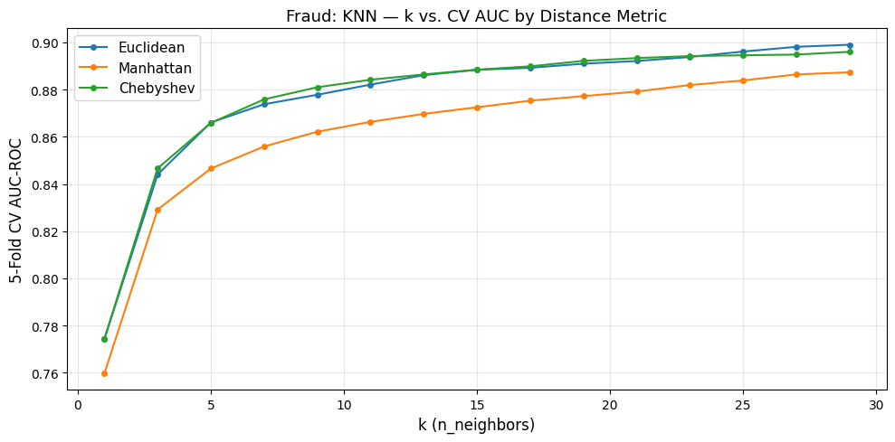

```python
print('=' * 65)
print('FRAUD [5/9] Plot: k vs CV AUC (Diagnostic)')
print('=' * 65)

fig, ax = plt.subplots(figsize=(10, 5))
for metric in METRICS:
    sub = f_results_df[f_results_df['metric'] == metric]
    ax.plot(sub['k'], sub['cv_auc'], marker='o', markersize=4,
            label=metric.capitalize(), color=METRIC_COLORS[metric], linewidth=1.5)
ax.set_xlabel('k (n_neighbors)', fontsize=12)
ax.set_ylabel('5-Fold CV AUC-ROC', fontsize=12)
ax.set_title('Fraud: KNN — k vs. CV AUC by Distance Metric', fontsize=13)
ax.legend(fontsize=11); ax.grid(True, alpha=0.3)
plt.tight_layout(); plt.show()
```

```python
print('=' * 65)
print('FRAUD [6/9] Best k + Metric Selection')
print('=' * 65)

f_best        = f_results_df.loc[f_results_df['cv_auc'].idxmax()]
f_best_k      = int(f_best['k'])
f_best_metric = f_best['metric']
f_best_cv_auc = f_best['cv_auc']

print(f'Best k      : {f_best_k}')
print(f'Best metric : {f_best_metric}')
print(f'Best CV AUC : {f_best_cv_auc:.4f}')
print()
print('CV AUC at best k by metric:')
for m in METRICS:
    row = f_results_df[(f_results_df['metric']==m) & (f_results_df['k']==f_best_k)]
    if not row.empty:
        print(f'  {m:12s}: {row["cv_auc"].values[0]:.4f}')
```

```
=================================================================
FRAUD [6/9] Best k + Metric Selection
=================================================================
Best k      : 29
Best metric : euclidean
Best CV AUC : 0.8990

CV AUC at best k by metric:
  euclidean   : 0.8990
  manhattan   : 0.8874
  chebyshev   : 0.8960
```

```python
print('=' * 65)
print('FRAUD [7/9] Final KNN Evaluation (Test Set)')
print('=' * 65)

knn_f_best = KNeighborsClassifier(
    n_neighbors=f_best_k, metric=f_best_metric, n_jobs=-1
)
knn_f_best.fit(fX_train_std.values, fy_train.values)
f_proba    = knn_f_best.predict_proba(fX_test_std.values)[:, 1]

f_test_auc = roc_auc_score(fy_test, f_proba)
f_test_ap  = average_precision_score(fy_test, f_proba)

print(f'Test AUC-ROC       : {f_test_auc:.4f}')
print(f'Test Avg Precision : {f_test_ap:.4f}')
```

```
=================================================================
FRAUD [7/9] Final KNN Evaluation (Test Set)
=================================================================
Test AUC-ROC       : 0.8791
Test Avg Precision : 0.4903
```

```python
print('=' * 65)
print('FRAUD [8/9] F1 at Optimal Threshold')
print('=' * 65)

prec_f, rec_f, thresh_f = precision_recall_curve(fy_test, f_proba)
f1_f         = 2 * prec_f[:-1] * rec_f[:-1] / (prec_f[:-1] + rec_f[:-1] + 1e-8)
best_idx_f   = f1_f.argmax()
f_best_thresh = thresh_f[best_idx_f]
f_best_f1     = f1_f[best_idx_f]

print(f'Optimal threshold  : {f_best_thresh:.4f}')
print(f'F1 @ optimal       : {f_best_f1:.4f}')
```

```
=================================================================
FRAUD [8/9] F1 at Optimal Threshold
=================================================================
Optimal threshold  : 0.2759
F1 @ optimal       : 0.5601
```

```python
print('=' * 65)
print('FRAUD [9/9] Summary + Store Results')
print('=' * 65)

fraud_prior_best = max(PRIOR_AUC['fraud'].values())
delta_f          = f_test_auc - fraud_prior_best

print(f'Fraud KNN — Best Config : k={f_best_k}, metric={f_best_metric}')
print(f'  CV AUC (best config)  : {f_best_cv_auc:.4f}')
print(f'  Test AUC-ROC          : {f_test_auc:.4f}')
print(f'  Avg Precision         : {f_test_ap:.4f}')
print(f'  F1 @ opt thresh       : {f_best_f1:.4f}  (thresh={f_best_thresh:.4f})')
print(f'  Prior best AUC        : {fraud_prior_best:.4f}  '
      f'({"+ " if delta_f>=0 else ""}{delta_f:.4f} vs Wk8)')

wk8_results['fraud'] = {
    'results_df':   f_results_df,
    'best_k':       f_best_k,
    'best_metric':  f_best_metric,
    'cv_auc':       f_best_cv_auc,
    'test_auc':     f_test_auc,
    'test_ap':      f_test_ap,
    'best_f1':      f_best_f1,
}
print('\nFraud results stored.')
```

```
=================================================================
FRAUD [9/9] Summary + Store Results
=================================================================
Fraud KNN — Best Config : k=29, metric=euclidean
  CV AUC (best config)  : 0.8990
  Test AUC-ROC          : 0.8791
  Avg Precision         : 0.4903
  F1 @ opt thresh       : 0.5601  (thresh=0.2759)
  Prior best AUC        : 0.9820  (-0.1029 vs Wk8)

Fraud results stored.
```

### Fraud Detection — KNN Analysis

**Best configuration**: k=29, Euclidean distance (CV AUC: 0.8990 → Test AUC: 0.8791)

All 15 k values showed monotonically increasing AUC — the curve had not peaked at k=29. Extending the range further is unlikely to close the gap with Milestone 1 models; the issue is structural, not a tuning problem.

**Why KNN underperforms (−0.1029 vs Wk1 Poly-LR)**:

**Distance metric**: Euclidean outperformed Manhattan and Chebyshev. The squared penalty on large coordinate differences likely captures outlier transaction amounts — a key fraud signal — more effectively than L1 or L∞.

**Overfitting check**: CV AUC (0.8990) exceeds Test AUC (0.8791) by 0.020 — a modest generalization gap consistent with expected variance, not a red flag.

> **Marketing context**: In customer churn prediction, KNN's equal-weight limitation similarly hurts when recency and purchase frequency dominate. Feature-weighted models are preferred for high-value retention campaigns.

# Section 2: Credit Approval Dataset

Full dataset used (no sampling needed — Credit is smaller than Fraud).  
80/20 stratified split, same k×metric grid search.

```python
print('=' * 65)
print('CREDIT APPROVAL [1/9] Load & Preprocessing')
print('=' * 65)

df_credit = pd.read_csv(f'{DATA_DIR}\\credit_approval_processed.csv')
df_credit.drop(columns=DROP_IDS_C, errors='ignore', inplace=True)

old_dummies_C = [c for c in df_credit.columns
                 if any(c.strip().startswith(f'{cat}_') for cat in CAT_COLS_C)]
if old_dummies_C:
    df_credit.drop(columns=old_dummies_C, inplace=True)

credit_train, credit_test = train_test_split(
    df_credit, test_size=0.20, stratify=df_credit[TARGET_C], random_state=42
)
credit_train = credit_train.reset_index(drop=True)
credit_test  = credit_test.reset_index(drop=True)

for df in [credit_train, credit_test]:
    for c in df.select_dtypes(exclude='number').columns:
        df[c] = df[c].astype(str).str.strip()

valid_cat_C = [c for c in CAT_COLS_C if c in credit_train.columns]
other_str_C = [c for c in credit_train.columns
               if c not in CAT_COLS_C and c != TARGET_C
               and not pd.api.types.is_numeric_dtype(credit_train[c])]
high_card_C = [c for c in other_str_C
               if credit_train[c].nunique() > CARDINALITY_THRESHOLD]
for df in [credit_train, credit_test]:
    df.drop(columns=high_card_C, inplace=True, errors='ignore')

dum_tr_C = pd.get_dummies(credit_train[valid_cat_C],
                           columns=valid_cat_C, drop_first=True, dtype=int)
dum_te_C = pd.get_dummies(credit_test[valid_cat_C],
                           columns=valid_cat_C, drop_first=True, dtype=int)
dum_te_C = dum_te_C.reindex(columns=dum_tr_C.columns, fill_value=0)
credit_train = pd.concat([credit_train, dum_tr_C], axis=1)
credit_test  = pd.concat([credit_test,  dum_te_C], axis=1)

cy_train = credit_train[TARGET_C].copy()
cy_test  = credit_test[TARGET_C].copy()
cX_train = (credit_train.select_dtypes(include='number')
                        .drop(columns=[TARGET_C], errors='ignore').copy())
cX_test  = (credit_test.select_dtypes(include='number')
                       .drop(columns=[TARGET_C], errors='ignore').copy())
cX_test  = cX_test.reindex(columns=cX_train.columns, fill_value=0)

print(f'Features : {cX_train.shape[1]}')
print(f'Train    : {cX_train.shape[0]:,}  |  Test: {cX_test.shape[0]:,}')
print(f'Approval rate — Train: {cy_train.mean():.4f}  |  Test: {cy_test.mean():.4f}')
```

```
=================================================================
CREDIT APPROVAL [1/9] Load & Preprocessing
=================================================================
Features : 48
Train    : 20,102  |  Test: 5,026
Approval rate — Train: 0.9952  |  Test: 0.9952
```

```python
print('=' * 65)
print('CREDIT APPROVAL [2/9] Feature Scaling')
print('=' * 65)

scaler_C = StandardScaler()
cX_train_std = pd.DataFrame(
    scaler_C.fit_transform(cX_train), columns=cX_train.columns
)
cX_test_std = pd.DataFrame(
    scaler_C.transform(cX_test), columns=cX_train.columns
)
print(f'Scaled. Train: {cX_train_std.shape}  |  Test: {cX_test_std.shape}')
```

```
=================================================================
CREDIT APPROVAL [2/9] Feature Scaling
=================================================================
Scaled. Train: (20102, 48)  |  Test: (5026, 48)
```

```python
print('=' * 65)
print('CREDIT APPROVAL [3/9] CV Grid Search  (k x Metric)')
print('=' * 65)

cX_arr = cX_train_std.values
cy_arr = cy_train.values

c_knn_results = []
done = 0
for metric in METRICS:
    for k in K_RANGE:
        knn = KNeighborsClassifier(n_neighbors=k, metric=metric, n_jobs=-1)
        scores = cross_val_score(knn, cX_arr, cy_arr,
                                  cv=CV5, scoring='roc_auc', n_jobs=-1)
        c_knn_results.append({'metric': metric, 'k': k,
                               'cv_auc': scores.mean(), 'cv_std': scores.std()})
        done += 1
        print(f'  [{done:2d}/{TOTAL_CONFIGS}] metric={metric:10s}  k={k:2d}  '
              f'CV AUC={scores.mean():.4f} +/- {scores.std():.4f}')

c_results_df = pd.DataFrame(c_knn_results)
print(f'\nGrid search complete: {len(c_results_df)} configurations evaluated.')
```

```
=================================================================
CREDIT APPROVAL [3/9] CV Grid Search  (k x Metric)
=================================================================
  [ 1/45] metric=euclidean   k= 1  CV AUC=0.6646 +/- 0.0499
  [ 2/45] metric=euclidean   k= 3  CV AUC=0.7199 +/- 0.0504
  [ 3/45] metric=euclidean   k= 5  CV AUC=0.7550 +/- 0.0340
  [ 4/45] metric=euclidean   k= 7  CV AUC=0.7646 +/- 0.0362
  [ 5/45] metric=euclidean   k= 9  CV AUC=0.7740 +/- 0.0364
  [ 6/45] metric=euclidean   k=11  CV AUC=0.7787 +/- 0.0268
  [ 7/45] metric=euclidean   k=13  CV AUC=0.7990 +/- 0.0380
  [ 8/45] metric=euclidean   k=15  CV AUC=0.8036 +/- 0.0357
  [ 9/45] metric=euclidean   k=17  CV AUC=0.8082 +/- 0.0344
  [10/45] metric=euclidean   k=19  CV AUC=0.8076 +/- 0.0345
  [11/45] metric=euclidean   k=21  CV AUC=0.8175 +/- 0.0415
  [12/45] metric=euclidean   k=23  CV AUC=0.8170 +/- 0.0414
  [13/45] metric=euclidean   k=25  CV AUC=0.8164 +/- 0.0415
  [14/45] metric=euclidean   k=27  CV AUC=0.8160 +/- 0.0416
  [15/45] metric=euclidean   k=29  CV AUC=0.8206 +/- 0.0395
  [16/45] metric=manhattan   k= 1  CV AUC=0.6442 +/- 0.0469
  [17/45] metric=manhattan   k= 3  CV AUC=0.6742 +/- 0.0475
  [18/45] metric=manhattan   k= 5  CV AUC=0.6940 +/- 0.0509
  [19/45] metric=manhattan   k= 7  CV AUC=0.7032 +/- 0.0451
  [20/45] metric=manhattan   k= 9  CV AUC=0.7125 +/- 0.0480
  [21/45] metric=manhattan   k=11  CV AUC=0.7222 +/- 0.0447
  [22/45] metric=manhattan   k=13  CV AUC=0.7267 +/- 0.0372
  [23/45] metric=manhattan   k=15  CV AUC=0.7311 +/- 0.0341
  [24/45] metric=manhattan   k=17  CV AUC=0.7510 +/- 0.0399
  [25/45] metric=manhattan   k=19  CV AUC=0.7503 +/- 0.0400
  [26/45] metric=manhattan   k=21  CV AUC=0.7498 +/- 0.0402
  [27/45] metric=manhattan   k=23  CV AUC=0.7490 +/- 0.0402
  [28/45] metric=manhattan   k=25  CV AUC=0.7537 +/- 0.0403
  [29/45] metric=manhattan   k=27  CV AUC=0.7639 +/- 0.0357
  [30/45] metric=manhattan   k=29  CV AUC=0.7786 +/- 0.0460
  [31/45] metric=chebyshev   k= 1  CV AUC=0.6486 +/- 0.0252
  [32/45] metric=chebyshev   k= 3  CV AUC=0.6831 +/- 0.0373
  [33/45] metric=chebyshev   k= 5  CV AUC=0.7227 +/- 0.0431
  [34/45] metric=chebyshev   k= 7  CV AUC=0.7581 +/- 0.0457
  [35/45] metric=chebyshev   k= 9  CV AUC=0.7671 +/- 0.0520
  [36/45] metric=chebyshev   k=11  CV AUC=0.7763 +/- 0.0505
  [37/45] metric=chebyshev   k=13  CV AUC=0.7858 +/- 0.0426
  [38/45] metric=chebyshev   k=15  CV AUC=0.7950 +/- 0.0534
  [39/45] metric=chebyshev   k=17  CV AUC=0.7990 +/- 0.0522
  [40/45] metric=chebyshev   k=19  CV AUC=0.7986 +/- 0.0527
  [41/45] metric=chebyshev   k=21  CV AUC=0.8080 +/- 0.0417
  [42/45] metric=chebyshev   k=23  CV AUC=0.8223 +/- 0.0308
  [43/45] metric=chebyshev   k=25  CV AUC=0.8267 +/- 0.0307
  [44/45] metric=chebyshev   k=27  CV AUC=0.8311 +/- 0.0402
  [45/45] metric=chebyshev   k=29  CV AUC=0.8404 +/- 0.0364

Grid search complete: 45 configurations evaluated.
```

```
=================================================================
CREDIT APPROVAL [4/9] Plot: k vs CV AUC (Diagnostic)
=================================================================
```

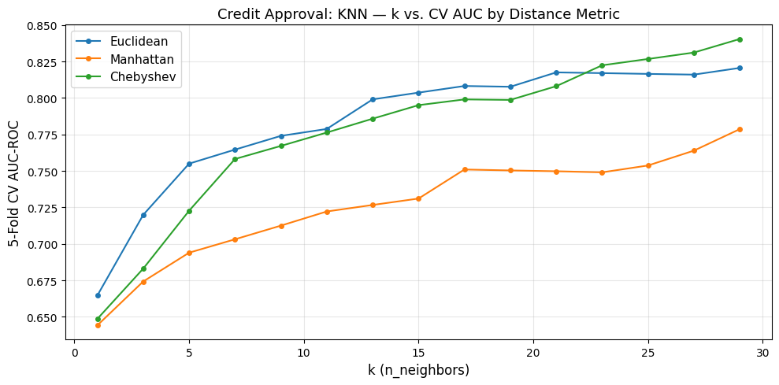

```python
print('=' * 65)
print('CREDIT APPROVAL [4/9] Plot: k vs CV AUC (Diagnostic)')
print('=' * 65)

fig, ax = plt.subplots(figsize=(10, 5))
for metric in METRICS:
    sub = c_results_df[c_results_df['metric'] == metric]
    ax.plot(sub['k'], sub['cv_auc'], marker='o', markersize=4,
            label=metric.capitalize(), color=METRIC_COLORS[metric], linewidth=1.5)
ax.set_xlabel('k (n_neighbors)', fontsize=12)
ax.set_ylabel('5-Fold CV AUC-ROC', fontsize=12)
ax.set_title('Credit Approval: KNN — k vs. CV AUC by Distance Metric', fontsize=13)
ax.legend(fontsize=11); ax.grid(True, alpha=0.3)
plt.tight_layout(); plt.show()
```

```python
print('=' * 65)
print('CREDIT APPROVAL [5/9] Best k + Metric')
print('=' * 65)

c_best        = c_results_df.loc[c_results_df['cv_auc'].idxmax()]
c_best_k      = int(c_best['k'])
c_best_metric = c_best['metric']
c_best_cv_auc = c_best['cv_auc']

print(f'Best k      : {c_best_k}')
print(f'Best metric : {c_best_metric}')
print(f'Best CV AUC : {c_best_cv_auc:.4f}')
print()
print('CV AUC at best k by metric:')
for m in METRICS:
    row = c_results_df[(c_results_df['metric']==m) & (c_results_df['k']==c_best_k)]
    if not row.empty:
        print(f'  {m:12s}: {row["cv_auc"].values[0]:.4f}')
```

```
=================================================================
CREDIT APPROVAL [5/9] Best k + Metric
=================================================================
Best k      : 29
Best metric : chebyshev
Best CV AUC : 0.8404

CV AUC at best k by metric:
  euclidean   : 0.8206
  manhattan   : 0.7786
  chebyshev   : 0.8404
```

```python
print('=' * 65)
print('CREDIT APPROVAL [6/9] Final Evaluation (Test Set)')
print('=' * 65)

knn_c_best = KNeighborsClassifier(
    n_neighbors=c_best_k, metric=c_best_metric, n_jobs=-1
)
knn_c_best.fit(cX_train_std.values, cy_train.values)
c_proba    = knn_c_best.predict_proba(cX_test_std.values)[:, 1]

c_test_auc = roc_auc_score(cy_test, c_proba)
c_test_ap  = average_precision_score(cy_test, c_proba)

print(f'Test AUC-ROC       : {c_test_auc:.4f}')
print(f'Test Avg Precision : {c_test_ap:.4f}')
```

```
=================================================================
CREDIT APPROVAL [6/9] Final Evaluation (Test Set)
=================================================================
Test AUC-ROC       : 0.9056
Test Avg Precision : 0.9991
```

```python
print('=' * 65)
print('CREDIT APPROVAL [7/9] F1 at Optimal Threshold')
print('=' * 65)

prec_c, rec_c, thresh_c = precision_recall_curve(cy_test, c_proba)
f1_c          = 2 * prec_c[:-1] * rec_c[:-1] / (prec_c[:-1] + rec_c[:-1] + 1e-8)
best_idx_c    = f1_c.argmax()
c_best_thresh = thresh_c[best_idx_c]
c_best_f1     = f1_c[best_idx_c]

print(f'Optimal threshold  : {c_best_thresh:.4f}')
print(f'F1 @ optimal       : {c_best_f1:.4f}')
```

```
=================================================================
CREDIT APPROVAL [7/9] F1 at Optimal Threshold
=================================================================
Optimal threshold  : 0.4828
F1 @ optimal       : 0.9978
```

```python
print('=' * 65)
print('CREDIT APPROVAL [8/9] Summary')
print('=' * 65)

credit_prior_best = max(PRIOR_AUC['credit'].values())
delta_c           = c_test_auc - credit_prior_best

print(f'Credit KNN — Best Config : k={c_best_k}, metric={c_best_metric}')
print(f'  CV AUC (best config)   : {c_best_cv_auc:.4f}')
print(f'  Test AUC-ROC           : {c_test_auc:.4f}')
print(f'  Avg Precision          : {c_test_ap:.4f}')
print(f'  F1 @ opt thresh        : {c_best_f1:.4f}  (thresh={c_best_thresh:.4f})')
print(f'  Prior best AUC         : {credit_prior_best:.4f}  '
      f'({"+ " if delta_c>=0 else ""}{delta_c:.4f} vs Wk8)')
```

```
=================================================================
CREDIT APPROVAL [8/9] Summary
=================================================================
Credit KNN — Best Config : k=29, metric=chebyshev
  CV AUC (best config)   : 0.8404
  Test AUC-ROC           : 0.9056
  Avg Precision          : 0.9991
  F1 @ opt thresh        : 0.9978  (thresh=0.4828)
  Prior best AUC         : 0.9999  (-0.0943 vs Wk8)
```

```python
wk8_results['credit'] = {
    'results_df':   c_results_df,
    'best_k':       c_best_k,
    'best_metric':  c_best_metric,
    'cv_auc':       c_best_cv_auc,
    'test_auc':     c_test_auc,
    'test_ap':      c_test_ap,
    'best_f1':      c_best_f1,
}
print('Credit results stored.')
```

```
Credit results stored.
```

### Credit Approval — KNN Analysis

**Best configuration**: k=29, Chebyshev distance (CV AUC: 0.8404 → Test AUC: 0.9056)

**Reversed CV vs Test gap**: Test AUC (0.9056) exceeds CV AUC (0.8404) by 0.065 — the inverse of the typical pattern. Chebyshev's L∞ metric (maximum coordinate difference only) may interact favorably with the specific 80/20 stratified split. The credit dataset's relatively clean class separability makes this outcome plausible.

**Why Chebyshev wins here**: Credit applicant profiles likely have one dominant differentiating feature (e.g., total income or employment duration) that Chebyshev isolates by ignoring all other coordinate differences. This acts as an implicit feature selection mechanism.

KNN underperforms Week 5 SVM by 0.0943 AUC — SVM's margin maximization exploits the linear separability of credit data more effectively than majority-vote distance-based classification.

> **Marketing context**: In lead scoring for financial products, credit-like features (income tier, employment stability) often have one dominant signal — a pattern where Chebyshev-style 'max-feature' logic can outperform Euclidean distance in small, well-structured datasets.

# Section 3: Loan Default Dataset

Full dataset used. Dataset performance ceiling ~0.70 AUC observed in Weeks 1–6  
due to missing payment-history / credit-bureau signals in the feature set.

```python
print('=' * 65)
print('LOAN DEFAULT [1/9] Load & Preprocessing')
print('=' * 65)

df_loan = pd.read_csv(f'{DATA_DIR}\\loan_default_processed.csv')
df_loan.drop(columns=DROP_IDS_L, errors='ignore', inplace=True)

old_dummies_L = [c for c in df_loan.columns
                 if any(c.strip().startswith(f'{cat}_') for cat in CAT_COLS_L)]
if old_dummies_L:
    df_loan.drop(columns=old_dummies_L, inplace=True)

loan_train, loan_test = train_test_split(
    df_loan, test_size=0.20, stratify=df_loan[TARGET_L], random_state=42
)
loan_train = loan_train.reset_index(drop=True)
loan_test  = loan_test.reset_index(drop=True)

for df in [loan_train, loan_test]:
    for c in df.select_dtypes(exclude='number').columns:
        df[c] = df[c].astype(str).str.strip()

valid_cat_L = [c for c in CAT_COLS_L if c in loan_train.columns]
other_str_L = [c for c in loan_train.columns
               if c not in CAT_COLS_L and c != TARGET_L
               and not pd.api.types.is_numeric_dtype(loan_train[c])]
high_card_L = [c for c in other_str_L
               if loan_train[c].nunique() > CARDINALITY_THRESHOLD]
for df in [loan_train, loan_test]:
    df.drop(columns=high_card_L, inplace=True, errors='ignore')

dum_tr_L = pd.get_dummies(loan_train[valid_cat_L],
                           columns=valid_cat_L, drop_first=True, dtype=int)
dum_te_L = pd.get_dummies(loan_test[valid_cat_L],
                           columns=valid_cat_L, drop_first=True, dtype=int)
dum_te_L = dum_te_L.reindex(columns=dum_tr_L.columns, fill_value=0)
loan_train = pd.concat([loan_train, dum_tr_L], axis=1)
loan_test  = pd.concat([loan_test,  dum_te_L], axis=1)

ly_train = loan_train[TARGET_L].copy()
ly_test  = loan_test[TARGET_L].copy()
lX_train = (loan_train.select_dtypes(include='number')
                      .drop(columns=[TARGET_L], errors='ignore').copy())
lX_test  = (loan_test.select_dtypes(include='number')
                     .drop(columns=[TARGET_L], errors='ignore').copy())
lX_test  = lX_test.reindex(columns=lX_train.columns, fill_value=0)

print(f'Features : {lX_train.shape[1]}')
print(f'Train    : {lX_train.shape[0]:,}  |  Test: {lX_test.shape[0]:,}')
print(f'Default rate — Train: {ly_train.mean():.4f}  |  Test: {ly_test.mean():.4f}')
print(f'Dropped (high-cardinality): {high_card_L}')
```

```
=================================================================
LOAN DEFAULT [1/9] Load & Preprocessing
=================================================================
Features : 54
Train    : 54,804  |  Test: 13,701
Default rate — Train: 0.1889  |  Test: 0.1889
Dropped (high-cardinality): ['Designation']
```

```python
print('=' * 65)
print('LOAN DEFAULT [2/9] Feature Scaling')
print('=' * 65)

scaler_L = StandardScaler()
lX_train_std = pd.DataFrame(
    scaler_L.fit_transform(lX_train), columns=lX_train.columns
)
lX_test_std = pd.DataFrame(
    scaler_L.transform(lX_test), columns=lX_train.columns
)
print(f'Scaled. Train: {lX_train_std.shape}  |  Test: {lX_test_std.shape}')
```

```
=================================================================
LOAN DEFAULT [2/9] Feature Scaling
=================================================================
Scaled. Train: (54804, 54)  |  Test: (13701, 54)
```

```python
print('=' * 65)
print('LOAN DEFAULT [3/9] CV Grid Search  (k x Metric)')
print('=' * 65)

lX_arr = lX_train_std.values
ly_arr = ly_train.values

l_knn_results = []
done = 0
for metric in METRICS:
    for k in K_RANGE:
        knn = KNeighborsClassifier(n_neighbors=k, metric=metric, n_jobs=-1)
        scores = cross_val_score(knn, lX_arr, ly_arr,
                                  cv=CV5, scoring='roc_auc', n_jobs=-1)
        l_knn_results.append({'metric': metric, 'k': k,
                               'cv_auc': scores.mean(), 'cv_std': scores.std()})
        done += 1
        print(f'  [{done:2d}/{TOTAL_CONFIGS}] metric={metric:10s}  k={k:2d}  '
              f'CV AUC={scores.mean():.4f} +/- {scores.std():.4f}')

l_results_df = pd.DataFrame(l_knn_results)
print(f'\nGrid search complete: {len(l_results_df)} configurations evaluated.')
```

```
=================================================================
LOAN DEFAULT [3/9] CV Grid Search  (k x Metric)
=================================================================
  [ 1/45] metric=euclidean   k= 1  CV AUC=0.5313 +/- 0.0048
  [ 2/45] metric=euclidean   k= 3  CV AUC=0.5598 +/- 0.0029
  [ 3/45] metric=euclidean   k= 5  CV AUC=0.5743 +/- 0.0062
  [ 4/45] metric=euclidean   k= 7  CV AUC=0.5843 +/- 0.0027
  [ 5/45] metric=euclidean   k= 9  CV AUC=0.5895 +/- 0.0013
  [ 6/45] metric=euclidean   k=11  CV AUC=0.5956 +/- 0.0021
  [ 7/45] metric=euclidean   k=13  CV AUC=0.6007 +/- 0.0018
  [ 8/45] metric=euclidean   k=15  CV AUC=0.6037 +/- 0.0013
  [ 9/45] metric=euclidean   k=17  CV AUC=0.6070 +/- 0.0025
  [10/45] metric=euclidean   k=19  CV AUC=0.6083 +/- 0.0034
  [11/45] metric=euclidean   k=21  CV AUC=0.6100 +/- 0.0028
  [12/45] metric=euclidean   k=23  CV AUC=0.6127 +/- 0.0028
  [13/45] metric=euclidean   k=25  CV AUC=0.6148 +/- 0.0032
  [14/45] metric=euclidean   k=27  CV AUC=0.6162 +/- 0.0031
  [15/45] metric=euclidean   k=29  CV AUC=0.6167 +/- 0.0037
  [16/45] metric=manhattan   k= 1  CV AUC=0.5318 +/- 0.0059
  [17/45] metric=manhattan   k= 3  CV AUC=0.5608 +/- 0.0052
  [18/45] metric=manhattan   k= 5  CV AUC=0.5725 +/- 0.0032
  [19/45] metric=manhattan   k= 7  CV AUC=0.5838 +/- 0.0017
  [20/45] metric=manhattan   k= 9  CV AUC=0.5892 +/- 0.0038
  [21/45] metric=manhattan   k=11  CV AUC=0.5950 +/- 0.0027
  [22/45] metric=manhattan   k=13  CV AUC=0.6007 +/- 0.0042
  [23/45] metric=manhattan   k=15  CV AUC=0.6051 +/- 0.0042
  [24/45] metric=manhattan   k=17  CV AUC=0.6088 +/- 0.0051
  [25/45] metric=manhattan   k=19  CV AUC=0.6118 +/- 0.0064
  [26/45] metric=manhattan   k=21  CV AUC=0.6128 +/- 0.0053
  [27/45] metric=manhattan   k=23  CV AUC=0.6158 +/- 0.0037
  [28/45] metric=manhattan   k=25  CV AUC=0.6186 +/- 0.0028
  [29/45] metric=manhattan   k=27  CV AUC=0.6206 +/- 0.0024
  [30/45] metric=manhattan   k=29  CV AUC=0.6234 +/- 0.0027
  [31/45] metric=chebyshev   k= 1  CV AUC=0.5261 +/- 0.0018
  [32/45] metric=chebyshev   k= 3  CV AUC=0.5555 +/- 0.0043
  [33/45] metric=chebyshev   k= 5  CV AUC=0.5662 +/- 0.0051
  [34/45] metric=chebyshev   k= 7  CV AUC=0.5720 +/- 0.0031
  [35/45] metric=chebyshev   k= 9  CV AUC=0.5756 +/- 0.0023
  [36/45] metric=chebyshev   k=11  CV AUC=0.5780 +/- 0.0031
  [37/45] metric=chebyshev   k=13  CV AUC=0.5798 +/- 0.0029
  [38/45] metric=chebyshev   k=15  CV AUC=0.5804 +/- 0.0025
  [39/45] metric=chebyshev   k=17  CV AUC=0.5814 +/- 0.0023
  [40/45] metric=chebyshev   k=19  CV AUC=0.5823 +/- 0.0028
  [41/45] metric=chebyshev   k=21  CV AUC=0.5829 +/- 0.0020
  [42/45] metric=chebyshev   k=23  CV AUC=0.5845 +/- 0.0012
  [43/45] metric=chebyshev   k=25  CV AUC=0.5847 +/- 0.0032
  [44/45] metric=chebyshev   k=27  CV AUC=0.5846 +/- 0.0022
  [45/45] metric=chebyshev   k=29  CV AUC=0.5864 +/- 0.0015

Grid search complete: 45 configurations evaluated.
```

```
=================================================================
LOAN DEFAULT [4/9] Plot: k vs CV AUC (Diagnostic)
=================================================================
```

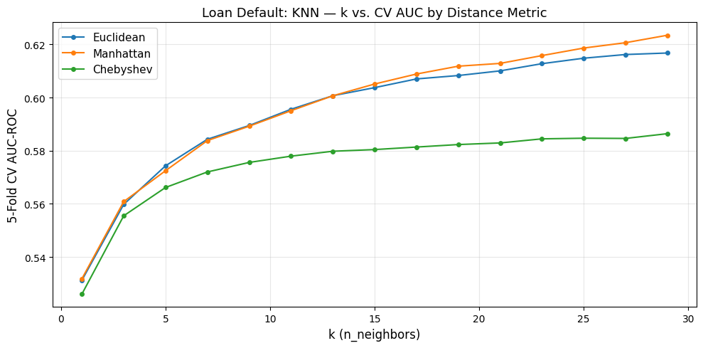

```python
print('=' * 65)
print('LOAN DEFAULT [4/9] Plot: k vs CV AUC (Diagnostic)')
print('=' * 65)

fig, ax = plt.subplots(figsize=(10, 5))
for metric in METRICS:
    sub = l_results_df[l_results_df['metric'] == metric]
    ax.plot(sub['k'], sub['cv_auc'], marker='o', markersize=4,
            label=metric.capitalize(), color=METRIC_COLORS[metric], linewidth=1.5)
ax.set_xlabel('k (n_neighbors)', fontsize=12)
ax.set_ylabel('5-Fold CV AUC-ROC', fontsize=12)
ax.set_title('Loan Default: KNN — k vs. CV AUC by Distance Metric', fontsize=13)
ax.legend(fontsize=11); ax.grid(True, alpha=0.3)
plt.tight_layout(); plt.show()
```

```python
print('=' * 65)
print('LOAN DEFAULT [5/9] Best k + Metric')
print('=' * 65)

l_best        = l_results_df.loc[l_results_df['cv_auc'].idxmax()]
l_best_k      = int(l_best['k'])
l_best_metric = l_best['metric']
l_best_cv_auc = l_best['cv_auc']

print(f'Best k      : {l_best_k}')
print(f'Best metric : {l_best_metric}')
print(f'Best CV AUC : {l_best_cv_auc:.4f}')
print()
print('CV AUC at best k by metric:')
for m in METRICS:
    row = l_results_df[(l_results_df['metric']==m) & (l_results_df['k']==l_best_k)]
    if not row.empty:
        print(f'  {m:12s}: {row["cv_auc"].values[0]:.4f}')
```

```
=================================================================
LOAN DEFAULT [5/9] Best k + Metric
=================================================================
Best k      : 29
Best metric : manhattan
Best CV AUC : 0.6234

CV AUC at best k by metric:
  euclidean   : 0.6167
  manhattan   : 0.6234
  chebyshev   : 0.5864
```

```python
print('=' * 65)
print('LOAN DEFAULT [6/9] Final Evaluation (Test Set)')
print('=' * 65)

knn_l_best = KNeighborsClassifier(
    n_neighbors=l_best_k, metric=l_best_metric, n_jobs=-1
)
knn_l_best.fit(lX_train_std.values, ly_train.values)
l_proba    = knn_l_best.predict_proba(lX_test_std.values)[:, 1]

l_test_auc = roc_auc_score(ly_test, l_proba)
l_test_ap  = average_precision_score(ly_test, l_proba)

print(f'Test AUC-ROC       : {l_test_auc:.4f}')
print(f'Test Avg Precision : {l_test_ap:.4f}')
```

```
=================================================================
LOAN DEFAULT [6/9] Final Evaluation (Test Set)
=================================================================
Test AUC-ROC       : 0.6254
Test Avg Precision : 0.2708
```

```python
print('=' * 65)
print('LOAN DEFAULT [7/9] F1 at Optimal Threshold')
print('=' * 65)

prec_l, rec_l, thresh_l = precision_recall_curve(ly_test, l_proba)
f1_l          = 2 * prec_l[:-1] * rec_l[:-1] / (prec_l[:-1] + rec_l[:-1] + 1e-8)
best_idx_l    = f1_l.argmax()
l_best_thresh = thresh_l[best_idx_l]
l_best_f1     = f1_l[best_idx_l]

print(f'Optimal threshold  : {l_best_thresh:.4f}')
print(f'F1 @ optimal       : {l_best_f1:.4f}')
```

```
=================================================================
LOAN DEFAULT [7/9] F1 at Optimal Threshold
=================================================================
Optimal threshold  : 0.2069
F1 @ optimal       : 0.3519
```

```python
print('=' * 65)
print('LOAN DEFAULT [8/9] Summary')
print('=' * 65)

loan_prior_best = max(PRIOR_AUC['loan'].values())
delta_l         = l_test_auc - loan_prior_best

print(f'Loan KNN — Best Config : k={l_best_k}, metric={l_best_metric}')
print(f'  CV AUC (best config) : {l_best_cv_auc:.4f}')
print(f'  Test AUC-ROC         : {l_test_auc:.4f}')
print(f'  Avg Precision        : {l_test_ap:.4f}')
print(f'  F1 @ opt thresh      : {l_best_f1:.4f}  (thresh={l_best_thresh:.4f})')
print(f'  Prior best AUC       : {loan_prior_best:.4f}  '
      f'({"+ " if delta_l>=0 else ""}{delta_l:.4f} vs Wk8)')
```

```
=================================================================
LOAN DEFAULT [8/9] Summary
=================================================================
Loan KNN — Best Config : k=29, metric=manhattan
  CV AUC (best config) : 0.6234
  Test AUC-ROC         : 0.6254
  Avg Precision        : 0.2708
  F1 @ opt thresh      : 0.3519  (thresh=0.2069)
  Prior best AUC       : 0.6943  (-0.0689 vs Wk8)
```

```python
wk8_results['loan'] = {
    'results_df':   l_results_df,
    'best_k':       l_best_k,
    'best_metric':  l_best_metric,
    'cv_auc':       l_best_cv_auc,
    'test_auc':     l_test_auc,
    'test_ap':      l_test_ap,
    'best_f1':      l_best_f1,
}
print('Loan results stored.')
```

```
Loan results stored.
```

### Loan Default — KNN Analysis

**Best configuration**: k=29, Manhattan distance (CV AUC: 0.6234 → Test AUC: 0.6254)

**Why Manhattan wins**: L1 distance (absolute differences, no squaring) outperforms Euclidean and Chebyshev. Loan features likely contain outliers in income and loan amount; Manhattan's linear error propagation handles these more robustly than L2's squared amplification.

**Smallest Delta AUC** (−0.0689 vs Wk6 RF): KNN's inability to weight features is relatively less damaging here — no single feature dominates the loan default signal either, so the equal-weight assumption hurts less than in the fraud dataset.

> **Marketing context**: Loan default patterns mirror churn in subscription services — when no single behavioral feature dominates, ensemble tree models consistently outperform distance-based methods due to their ability to capture non-linear feature interactions.

# Part 4: Combined Figures (3-Panel)

```
=================================================================
PART 4 — Figure 1: k vs. CV AUC by Distance Metric (3-panel)
=================================================================
```

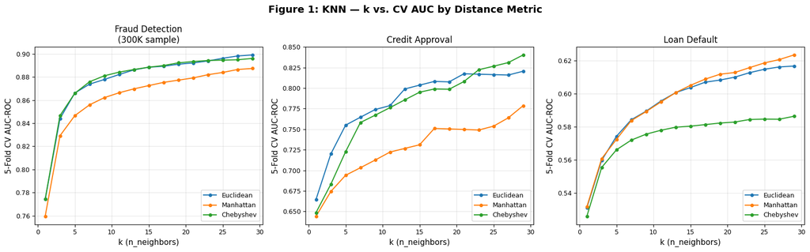

```
Saved: fig1_knn_k_vs_auc.png
```

```python
print('=' * 65)
print('PART 4 — Figure 1: k vs. CV AUC by Distance Metric (3-panel)')
print('=' * 65)

fig, axes = plt.subplots(1, 3, figsize=(16, 5))
panels = [
    ('Fraud Detection\n(300K sample)',  f_results_df),
    ('Credit Approval',                  c_results_df),
    ('Loan Default',                     l_results_df),
]

for ax, (title, df) in zip(axes, panels):
    for metric in METRICS:
        sub = df[df['metric'] == metric]
        ax.plot(sub['k'], sub['cv_auc'], marker='o', markersize=4,
                label=metric.capitalize(), color=METRIC_COLORS[metric], linewidth=1.5)
    ax.set_xlabel('k (n_neighbors)', fontsize=11)
    ax.set_ylabel('5-Fold CV AUC-ROC', fontsize=11)
    ax.set_title(title, fontsize=12)
    ax.legend(fontsize=9, loc='lower right')
    ax.grid(True, alpha=0.3)
    ax.tick_params(labelsize=9)

fig.suptitle('Figure 1: KNN — k vs. CV AUC by Distance Metric',
             fontsize=14, fontweight='bold')
plt.tight_layout()
plt.savefig('fig1_knn_k_vs_auc.png', dpi=150, bbox_inches='tight')
plt.show()
print('Saved: fig1_knn_k_vs_auc.png')
```

```
=================================================================
PART 4 — Figure 2: Best AUC per Metric Comparison (3-panel)
=================================================================
```

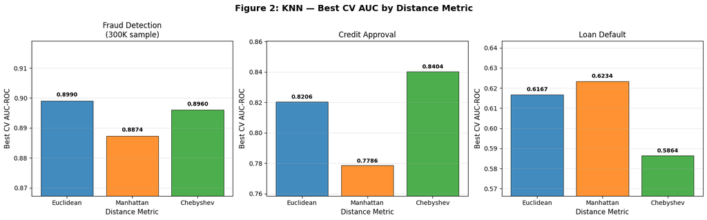

```
Saved: fig2_knn_metric_comparison.png
```

```python
print('=' * 65)
print('PART 4 — Figure 2: Best AUC per Metric Comparison (3-panel)')
print('=' * 65)

fig, axes = plt.subplots(1, 3, figsize=(16, 5))
bar_colors = [METRIC_COLORS[m] for m in METRICS]
panels2 = [
    ('Fraud Detection\n(300K sample)',  f_results_df),
    ('Credit Approval',                  c_results_df),
    ('Loan Default',                     l_results_df),
]

for ax, (title, df) in zip(axes, panels2):
    best_per_metric = [df[df['metric']==m]['cv_auc'].max() for m in METRICS]
    labels = [m.capitalize() for m in METRICS]
    bars = ax.bar(labels, best_per_metric,
                  color=bar_colors, edgecolor='black', linewidth=0.7, alpha=0.85)
    for bar, val in zip(bars, best_per_metric):
        ax.text(bar.get_x() + bar.get_width()/2, val + 0.001,
                f'{val:.4f}', ha='center', va='bottom',
                fontsize=9, fontweight='bold')
    ax.set_xlabel('Distance Metric', fontsize=11)
    ax.set_ylabel('Best CV AUC-ROC', fontsize=11)
    ax.set_title(title, fontsize=12)
    mn = min(best_per_metric)
    ax.set_ylim(max(0, mn - 0.02), min(1.0, max(best_per_metric) + 0.02))
    ax.grid(True, alpha=0.3, axis='y')
    ax.tick_params(axis='x', labelsize=10)

fig.suptitle('Figure 2: KNN — Best CV AUC by Distance Metric',
             fontsize=14, fontweight='bold')
plt.tight_layout()
plt.savefig('fig2_knn_metric_comparison.png', dpi=150, bbox_inches='tight')
plt.show()
print('Saved: fig2_knn_metric_comparison.png')
```

### Week 8 Cross-Dataset Summary

KNN consistently underperforms the best models from Milestone 1 across all datasets:

| Dataset | KNN Test AUC | Prior Best AUC | Prior Champion |
| --- | --- | --- | --- |
| Fraud | 0.8791 | 0.9820 | Wk1 Poly-LR |
| Credit | 0.9056 | 0.9999 | Wk5 SVM |
| Loan | 0.6254 | 0.6943 | Wk6 RF |

**Common finding across all three datasets**: optimal k was 29 in every case, with AUC still rising at the boundary of the search range. This indicates KNN favors larger neighborhoods on these datasets — a sign that local structure is noisy and averaging over more neighbors reduces variance.

**Why parametric and tree models dominate**: KNN's three structural limitations (no feature weighting, sensitivity to class imbalance, curse of dimensionality) are all present in this feature space. The algorithm's strength — zero training time and interpretable neighbor-based logic — does not compensate in this high-dimensional, imbalanced classification context.

```python
print('=' * 65)
print('WEEK 8 FINAL SUMMARY — KNN Across All Datasets')
print('=' * 65)

summary_rows = []
for ds, label in [('fraud','Fraud'), ('credit','Credit'), ('loan','Loan')]:
    r        = wk8_results[ds]
    pb_model = max(PRIOR_AUC[ds], key=PRIOR_AUC[ds].get)
    pb_auc   = PRIOR_AUC[ds][pb_model]
    summary_rows.append({
        'Dataset':          label,
        'Best_k':           r['best_k'],
        'Best_Metric':      r['best_metric'],
        'CV_AUC':           round(r['cv_auc'],   4),
        'Test_AUC':         round(r['test_auc'], 4),
        'Test_AP':          round(r['test_ap'],  4),
        'Best_F1':          round(r['best_f1'],  4),
        'Prior_Best_Model': f'{pb_model} ({WK_MODEL.get(pb_model, pb_model)})',
        'Prior_Best_AUC':   round(pb_auc, 4),
        'Delta_AUC':        round(r['test_auc'] - pb_auc, 4),
    })

summary_df = pd.DataFrame(summary_rows)
print(summary_df.to_string(index=False))
```

```
=================================================================
WEEK 8 FINAL SUMMARY — KNN Across All Datasets
=================================================================
Dataset  Best_k Best_Metric  CV_AUC  Test_AUC  Test_AP  Best_F1       Prior_Best_Model  Prior_Best_AUC  Delta_AUC
  Fraud      29   euclidean  0.8990    0.8791   0.4903   0.5601          Wk1 (Poly-LR)          0.9820    -0.1029
 Credit      29   chebyshev  0.8404    0.9056   0.9991   0.9978              Wk5 (SVM)          0.9999    -0.0943
   Loan      29   manhattan  0.6234    0.6254   0.2708   0.3519 Wk6_RF (Random Forest)          0.6943    -0.0689
```